# 五粮液与泸州老窖对比分析（营销策略与渠道板块）

## 1. 关键结论概览

1. **营销效率的剪刀差**：五粮液凭借历史积淀的品牌势能，维持着极低的销售费用率（<10%），进入了品牌红利收割期；而泸州老窖虽然销售费用率呈下降趋势（从18.56%降至11.8%），但仍处于通过高投入换取市场份额的进攻期，其品牌拉力对费用的依赖度依然显著高于五粮液。
2. **渠道模式的二元对立**：五粮液正处于从“大商制”向“扁平化控盘”艰难转型的深水区，试图通过数字化手段回收定价权，但面临大商利益集团的顽强博弈；泸州老窖则通过“品牌专营模式”实现了渠道的准军事化管理，通过股权捆绑将经销商转化为“合伙人”，执行力极强，但在下行周期中面临经销商资金链断裂的高风险。
3. **价值链的利润重构**：在普遍的价格倒挂现象下，五粮液渠道的生存逻辑转向“高周转、低毛利”，依赖厂家年底的模糊返利维持生计；泸州老窖渠道则依赖“高资金门槛、高股权分红”，其抗风险能力高度绑定于国窖1573的批价稳定性与分红预期。

## 2. 营销策略：资源配置与费效比博弈

### 2.1 营销投入的量级与趋势分析

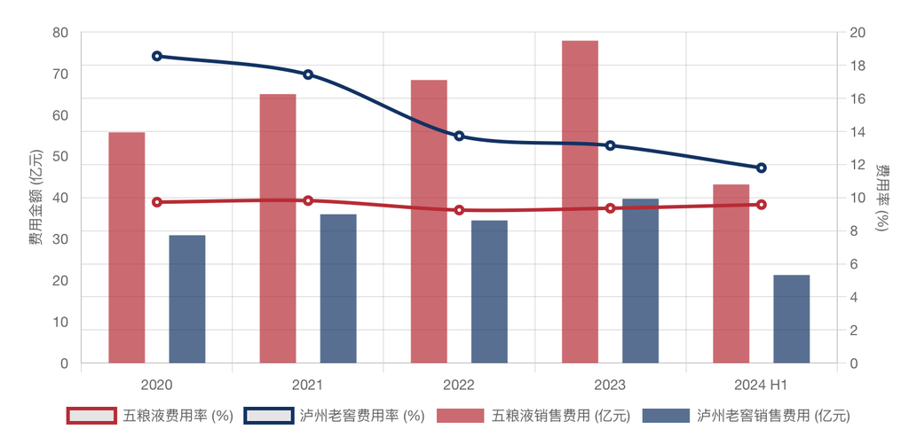

财务数据是企业战略意图最真实的映射。通过对2020年至2024年上半年的销售费用进行纵向回溯，我们发现了两者在资源投入上的显著差异。

**表 2-1：五粮液与泸州老窖销售费用及费率变动趋势 (2020-2024 H1)**

| **指标** | **2020** | **2021** | **2022** | **2023** | **2024 (H1)** | **趋势解读** |
| --- | --- | --- | --- | --- | --- | --- |
| **五粮液销售费用 (亿元)** | 55.79 | 65.04 | 68.44 | 77.96 | 43.2 | 随营收规模稳步扩张，绝对值巨大 |
| **泸州老窖销售费用 (亿元)** | 30.91 | 35.99 | 34.49 | 39.74 | 21.3 | 投入力度波动上升，增速略有放缓 |
| **五粮液销售费用率 (%)** | 9.73% | 9.82% | 9.25% | 9.36% | 9.58% | **极为稳定**，长期控制在10%以内 |
| **泸州老窖销售费用率 (%)** | 18.56% | 17.44% | 13.73% | 13.15% | 11.80% | **显著下降**，营销效率大幅提升 |

五粮液的销售费用率长期稳定在个位数，这在快消品行业属于极高品牌势能的表现。这主要得益于其作为“浓香之王”的存量认知优势，产品自带流量，无需过度的推力即可实现动销。这种低费率结构赋予了五粮液极高的净利润安全垫，使其在应对价格战时拥有更深厚的底气。

相比之下，泸州老窖在2020年的销售费用率高达18.56%，几近五粮液的两倍。这反映了其当时为了通过“国窖1573”重回前三，采取了激进的饱和式攻击策略。然而，值得注意的是，该比率在过去四年中呈现出清晰的下降趋势，至2024年上半年已降至11.8%。这一变化不仅仅是成本控制的结果，更意味着**随着国窖1573在千元价格带的站稳脚跟，其品牌复兴的初期高投入阶段已接近尾声，边际营销成本开始递减，进入了利润释放期。** 这一趋势若能持续，泸州老窖的净利率提升空间将十分可观 。

### 2.2 资源配置的结构性差异

深入分析营销费用的内部构成，可以揭示两家企业截然不同的战术打法:

- 五粮液：渠道推力主导

> 以2024年上半年数据为例，五粮液的促销费用占比高达64.11%。这意味着五粮液将绝大部分营销资源投向了B端渠道，用于支付陈列费、开瓶费、经销商激励以及终端建设。这种策略的核心逻辑是“渠道为王”，通过满足渠道成员的利益诉求，利用庞大的终端网络将产品“推”向消费者。对于五粮液这种具有高自然流通率的硬通货，维持渠道的推力是防止库存积压的关键。
- 泸州老窖：品牌拉力主导

> 与五粮液形成鲜明对比，泸州老窖的广告宣传费占比最高，达到47.24%。这表明其战略重心仍在于C端消费者的心智建设。由于历史上曾经出现过品牌定位失误，泸州老窖必须持续通过高举高打的媒体投放、高端品鉴会以及公关活动，来修复并提升品牌价值感，从而产生强大的“品牌拉力”，吸引消费者主动指名购买。这种结构也解释了为何其销售费用率虽然下降但绝对值依然较高——高端品牌的声量维护是一场昂贵的持久战。

## 3. 消费者认知护城河：品牌资产的定性研究

在高端白酒领域，消费者认知是比财务数据更具前瞻性的指标。我们的调研揭示了两者在心智份额上的“存量”与“增量”特征。

### 3.1 认知的稳定性与顽固性

九十年代至今，中国白酒消费者的品牌阶梯已基本固化。

- **五粮液的“硬通货”属性**：经过长期的积淀，五粮液在消费者心中已形成了“高端白酒代名词”的认知，具有极强的稳定性。这种认知不因短期的产品迭代或价格波动而轻易改变。在商务宴请与礼赠场景中，五粮液的社交货币属性仅次于茅台，这种“面子价值”是其最大的护城河。
- **泸州老窖的“认知断层”**：泸州老窖因历史上的“名酒变民酒”策略失误，导致品牌力受损。虽然目前通过“国窖1573”成功重返高端，但消费者认知存在明显的割裂：认可“国窖1573”是高端酒，但对母品牌“泸州老窖”的认知往往停留在中端甚至大众酒层面。这种认知的**模糊性**限制了泸州老窖母品牌旗下其他产品的溢价能力，导致其高度依赖国窖1573这一单品打天下。

【消费者认知洞察】在实际调研中，消费者一致认同五粮液为高端品牌；但对于泸州老窖，普遍认为其品类较多，只有“国窖1573”属于高端白酒，整体品牌形象被中低端产品稀释。这意味着泸州老窖在未来的品牌建设中，仍需解决“品牌聚焦”与“产品矩阵”之间的矛盾。

### 3.2 地域版图的割据与渗透

品牌势能的落地具有显著的地域性，这与当地的经济状况及饮酒习惯密切相关。

- **河南市场（五粮液腹地）**：作为人口大省与白酒消费高地，河南消费者对五粮液的认可度极高且呈现顽固性。五粮液在此拥有深厚的政商务消费基础，泸州老窖虽投入巨大，但难以撼动五粮液的主导地位（e.g.“河南会战”的失败）。
- **川冀鲁市场（泸州老窖根据地）**：在四川本土、河北及山东部分地级市，泸州老窖凭借早期的渠道下沉与口感适应性，实现了对五粮液的反超。特别是在低度酒盛行的河北市场，国窖1573的低度系列表现优异。这种地域性的割据表明，高端白酒的竞争并非全国一盘棋，而是无数个区域市场的巷战 。

## 4. 渠道模式重构：权力结构的演变

### 4.1 渠道核心矛盾模型

在深入分析具体模式前，我们需要建立一个“厂商-经销商博弈模型”。白酒行业的渠道核心矛盾始终围绕以下四个维度展开：

1. **资金杠杆**：厂家希望利用经销商的预付款来平滑现金流，经销商希望减少资金占用以降低财务成本。
2. **库存缓冲**：厂家需要经销商承担库存以调节生产节奏，经销商恐惧库存积压导致跌价损失。
3. **市场拓展**：厂家追求市场覆盖率与占有率，经销商追求单店利润与区域垄断。
4. **经营权让渡**：厂家希望掌控终端数据与最终定价权，经销商希望保留“暗箱操作”的利润空间与客户资源。

### 4.2 五粮液：从“诸侯割据”到“中央集权”

五粮液的渠道历史是典型的“大商制”产物。历史上，超级大商掌握了极高的话语权甚至定价权，甚至出现了“大商绑架厂家”的局面。近年来的改革可以概括为“控盘分利”下的中央集权化。

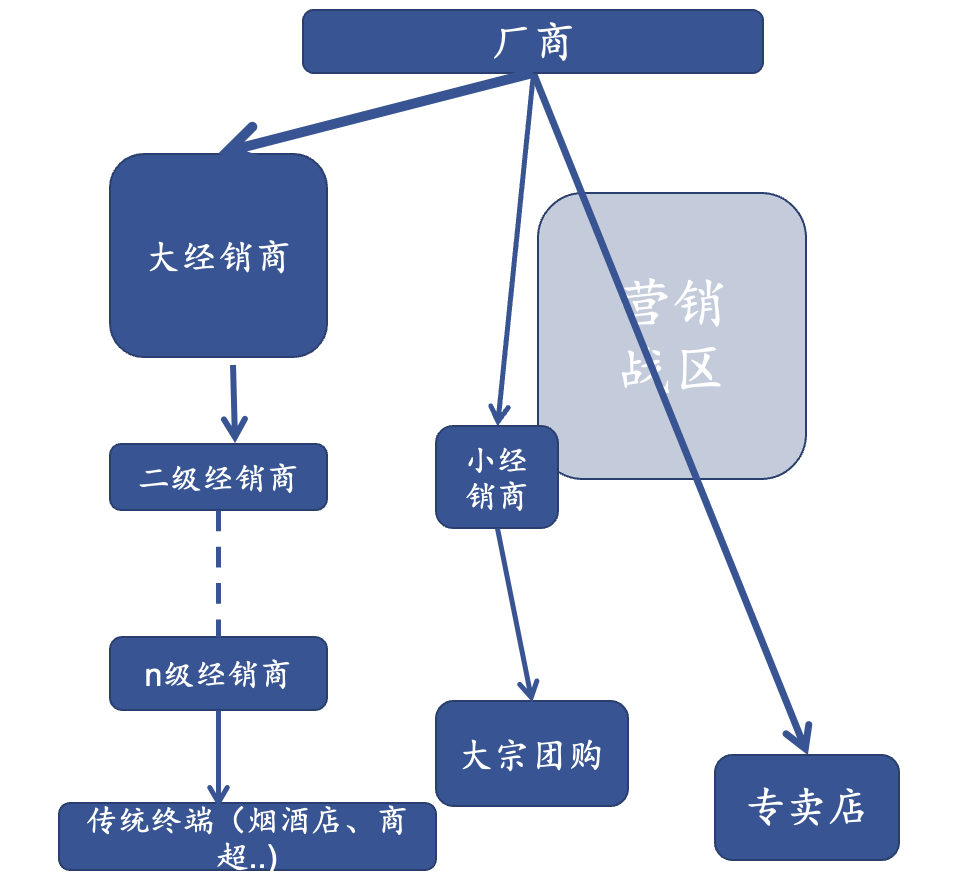

五粮液现存渠道结构

- **改革路径：**
  1. **削藩（削减大商计划量）**：五粮液强行减少传统大经销商的配额，将这一部分高毛利产品通过“直销体系”或“团购渠道”消化，以此降低对大商的依赖，并提升厂家毛利。
  2. **扁平化（百城千县万店）**：推进渠道极度下沉，直接对接终端烟酒店与商超。这本质上是将渠道链条缩短，试图跳过二级、三级批发商，直接掌握终端动销数据，实现“厂家-终端”的直连。
  3. **控盘分利**：引入数字化扫码系统，监控每一瓶酒的流向。厂家通过扫码返利直接控制终端店和消费者，试图从大商手中回收定价权与促销权。
- **痛点分析**：体系不稳。大商作为五粮液多年的资金池与缓冲垫，其利益受损后积极性下降。在市场遇冷时，大商不再愿意无条件“挺价”，反而可能为了回笼资金低价甩货，导致批价松动，进而影响品牌形象。五粮液目前正处于旧势力未去、新体系未稳的尴尬期。

### 4.3 泸州老窖：柒泉模式的终局——品牌专营

泸州老窖的渠道进化更为激进，经历了从“柒泉模式”到“品牌专营模式”的迭代。其核心逻辑是“资本捆绑”与“准军事化管理”。

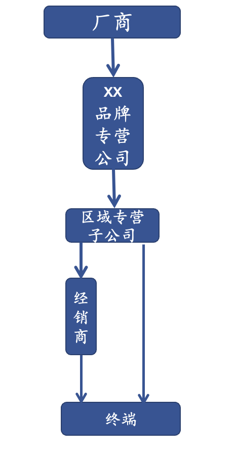

泸州老窖现存渠道结构

**表 4-1：五粮液与泸州老窖渠道模式深度对比**

| **维度** | **五粮液（后大商时代）** | **泸州老窖（品牌专营模式）** |
| --- | --- | --- |
| **渠道层级** | 正在压缩，试图扁平化，但仍存多级批发 | 严格扁平（三级架构） |
| **经销商角色** | 贸易商、物流商、资金垫付者 | 股东、合伙人、资金平台 |
| **终端掌控力** | 弱（依赖大商渗透），正在通过数字化加强 | 强（厂家人员直接管理，指令直达） |
| **利润来源** | 进销差价 + 年终模糊返利 | 进销差价 + 股权分红 + 投资收益 |
| **改革阻力** | 极大（大商利益集团盘根错节） | 较小（体系已固化，利益高度一致） |

## 5. 盈利结构分析：单店模型与渠道链条

### 5.1 渠道价值链利润模型

我们构建了一个典型的千元级白酒渠道利润链条，以展示资金在各个环节的流转与损耗。

**表 5-1：单瓶白酒渠道价值链测算（假设模型）**

| **环节** | **五粮液模式（普五）** | **泸州老窖模式（国窖1573）** | **逻辑解析** |
| --- | --- | --- | --- |
| **出厂价** | ~969元 | ~960-980元 | 厂家名义结算价，通常高于市场实际批发价。 |
| **一批价** | ~930-940元 | ~900-920元 | **价格倒挂**。经销商以低于出厂价的价格向二批或终端出货。 |
| **倒挂缺口** | -30元至-40元 | -40元至-60元 | 经销商每卖一瓶酒，账面现金亏损数十元。 |
| **终端进货价** | ~950元 | ~920元 | 终端烟酒店的拿货成本。 |
| **终端零售成交价** | ~1050-1100元 | ~1000-1050元 | 消费者实际支付价格。 |
| **渠道总毛利** | ~100-150元 | ~80-130元 | 整个渠道链条的利润空间日益被压缩。 |
| **利润回补机制** | **模糊返利**：厂家年底根据销量给予每瓶50-80元的返利，填补倒挂缺口并产生微利。 | **股权分红+返利**：除销量返利外，经销商依赖专营公司的年度分红来实现综合盈利。 |  |

当前的白酒渠道实质上运行着一种隐性金融契约：

- **五粮液的“对赌”**：经销商之所以愿意亏本卖（倒挂），是因为相信五粮液的品牌信誉，确信年底的“模糊返利”能覆盖亏损并带来利润。这是一种基于销量的对赌。一旦动销放缓，或者厂家返利兑现不及时，经销商的现金流将可能断裂，引发抛售。
- **泸州老窖的“锁仓”**：经销商投入巨额资金入股，不仅是为了卖酒差价，更是为了分红。这种模式将经销商锁死在战车上，增加了退出的沉没成本。但在市场低迷时，这种高资金占用会成为巨大的负担。

### 5.2 单经销商盈利模型压力测试

**场景：年销售额1000万的经销商**

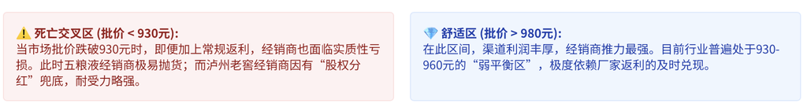

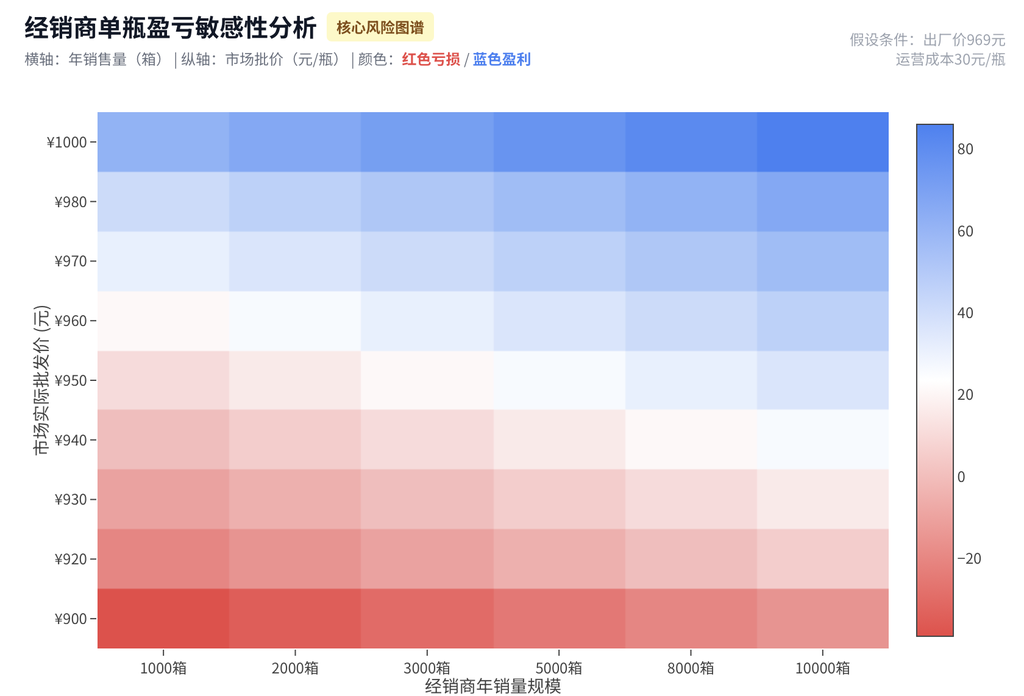

- **五粮液经销商：**
  - **核心痛点**：量价悖论。厂家为了完成报表增长，倾向于不断压货（量增），导致批价下跌（价跌）。
  - **盈利逻辑**：依靠极高的周转率。虽然单瓶利润极薄（甚至只赚返利），但因为五粮液好卖，资金周转快，年化回报率尚可。
  - **风险点**：库存积压。一旦周转慢下来，资金成本（利息）将吃掉微薄的利润。
- **泸州老窖经销商：**
  - **核心痛点**：资金高压。品牌专营模式要求预付大量资金，且有入股资金沉淀。
  - **盈利逻辑**：高门槛带来的垄断收益。通过严控终端，维持较高的终端价。
  - **风险点**：根据反馈，已有部分中小经销商因“不堪重负”而主动退出。这说明当动销不畅时，分红预期下降，高昂的资金占用成本使得该模型的ROI变得不再具有吸引力。

## 6. 应对与展望：存量博弈下的破局之道

### 6.1 渠道反应与策略调整

面对相似的市场压力，两家企业的渠道反应表现出明显的差异：

- **五粮液的维稳**：面对体系不稳，五粮液的核心诉求是“稳大商、扶小商”。策略上，一方面通过控量来试图挺价，另一方面通过数字化手段让返利更透明、更及时，以安抚经销商情绪。其核心关注点在于如何平衡大商利益与渠道扁平化改革之间的矛盾。
- **泸州老窖的筛选**：面对经销商的主动退出，泸州老窖表现出一种“优胜劣汰”的态度。其品牌专营模式本质上是一个筛选器，留下的都是资金实力雄厚、忠诚度极高的商家。策略上，通过高强度的停货挺价，维持国窖1573的高端形象，保障核心经销商的资产价值不缩水。

### 6.2 未来演进预测

1. **营销费用临界点**：五粮液的低费率模式可持续性较强，但需警惕品牌老化，同时需要在“差异性”之外打造足够明显的“优势”， 争取拿回一部分定义白酒价值的话语权，如**在白酒金融属性（茅台）之外强调白酒品质**；泸州老窖的费率下降一方面可被视作品牌声量在投入积累之下提升后公司的主动选择，**但也意味投入营销费用对品牌认知增强的边际效用递减**，需关注泸州老窖能否以及何时才能真正实现品牌认知方面的“质变”。
2. **渠道模式融合**：未来两者可能会出现某种程度的融合。五粮液正在学习泸州老窖的“控盘”能力，加强对终端的掌控；而泸州老窖在压力之下，也可能适当放松资金要求，给予经销商更多的喘息空间。

**建议关注：**

1. 一批价：直接反映渠道信心。
2. 销售费用率拐点：观察泸州老窖是否能维持低费率下的增长，验证其品牌势能能否固化。
3. 品牌量价策略：在资本市场态度和决策层战略考虑双重影响下，品牌是否明确传递出“增量”或“减价”的信号。
4. 返利及回款要求：品牌根据实际情况调整的幅度是否足以支持经销商继续经营。